# Assignment_3

Camille Kaczmar

2024-03-09

```r
library(tidyverse)
library(purrr)
```

# Introduction

This analysis explores the power required for different car types on a highway. We extend the analysis by adding a new super light car and computing mean and maximum power across sampled speeds using two methods: FOR loops and the pmap function.

## Car Specifications

Now, we define the specifications for each car type, including the new super light car.

```r
possible_cars <- data.frame(
  name = c("A", "B", "C", "Super Light"),
  mass = c(20000, 65000, 38000, 5000), # in kg
  area = c(22, 30, 22, 10) # in m^2
)
```

## Generating Sampled Speeds

We generate speeds centered around the mean highway speed of 80 km/hr with a standard deviation of 10km/hr.

```r
set.seed(123) # For reproducibility
nsample <- 200
mean_speed <- 80 # km/hr
sd_speed <- 10 # km/hr

speed_samples <- rnorm(n = nsample, mean = mean_speed, sd = sd_speed)
```

## Method 1: Using FOR Loop

This code block does the following:

- Initializes variables and generates 100 sample speeds based on the specified mean and standard deviation, converted to m/s.
- Loops through each car type defined in possible_cars.
- For each car, it loops through each of the 100 sampled speeds, calculates power using the autopower function, and stores these power values.
- Calculates mean and maximum power from the generated power values for each car.
- Stores these calculations in the results data frame for later analysis.

```r
# If we needed the autopower function loaded:
## source("C:/Users/camil/OneDrive/Documents/UCSB/ESM262/ESM_262_Repo/R/autopower.)

# Generate speeds in m/s from a normally distributed set of speeds in km/hr
set.seed(123) # Ensure reproducibility
nsample = 100
mean_speed_kmh = 80
sd_speed_kmh = 10
mean_speed_ms = mean_speed_kmh / 3.6
sd_speed_ms = sd_speed_kmh / 3.6

# Initialize data frames to store results
results <- data.frame(car = character(), mean_power = numeric(), max_power = numeric(), stringsAsFactors = FALSE)

powers <- as.data.frame(matrix(ncol=4, nrow=nsample))
colnames(powers) = possible_cars$name

# Loop through each car type
for (i in 1:nrow(possible_cars)) {
  car <- possible_cars$name[i]
  speeds <- rnorm(nsample, mean = mean_speed_ms, sd = sd_speed_ms)


    powers[,i] <- autopower(V = speeds, A = possible_cars$area[i], m = possible_cars$mass[i])


  mean_power <- mean(powers[,i])
  max_power <- max(powers[,i])

  results <- rbind(results, data.frame(car = car, mean_power = mean_power, max_power = max_power))
}

### Pivot powers data frame longer
powers_pivot <- pivot_longer(powers,cols = A:'Super Light',names_to = "cars",values_to = "powers")


results
```

```
##           car mean_power max_power
## 1           A  1225818.3 1544212.5
## 2           B  3884498.5 5534344.9
## 3           C  2336796.9 2962715.0
## 4 Super Light   301854.7  401097.6
```

## Method 2: Using pmap

For Method 2, we’ll use the pmap function from the purrr package to efficiently compute mean and maximum power for each car type across sampled speeds. This method is particularly useful when you want to apply a function to each row of a data frame or list, using elements from each row as arguments to the function.

Assuming you have already defined your autopower function correctly and it is sourced into your R session, let’s proceed with using pmap for this task.

### Preparing Speed Samples

First, generate a vector of speeds based on a normal distribution converted from km/hr to m/s, just like in Method 1:

```r
# Assuming mean speed of 80 km/hr and standard deviation of 10 km/hr
mean_speed_kmh <- 80
sd_speed_kmh <- 10
nsample <- 100

# Convert mean and sd to m/s
mean_speed_ms <- mean_speed_kmh / 3.6
sd_speed_ms <- sd_speed_kmh / 3.6

# Generate speeds
set.seed(123) # for reproducibility
speeds_ms <- rnorm(nsample, mean = mean_speed_ms, sd = sd_speed_ms)
```

With pmap, you can create a list where each element corresponds to the arguments of the autopower function (except for speeds, which you’ll handle separately) and then apply autopower across all combinations of arguments.

Here’s how to use pmap for computing the mean and maximum power for each car type, assuming possible_cars dataframe is already defined:

```r
# Ensure the autopower function can accept vectors and returns vector of powers
autopower <- function(V, A, m) {
  g <- 9.8 # m/s^2
  rho <- 1.225 # kg/m^3
  cdrag <- 0.3 # Coefficient of drag
  Pb <- (0.5 * rho * A * cdrag * V^3) + (m * g * V)
  return(Pb)
}

# Function to compute mean and max power for a given car and speeds
compute_powers <- function(A, m, speeds) {
  powers <- pmap_dbl(list(V = speeds), autopower, A = A, m = m)
  return(list(powers=powers))
}


# Apply compute_powers for each car
results_pmap <- map2_dfc(possible_cars$area, possible_cars$mass, ~compute_powers(.x, .y, speeds_ms))
colnames(results_pmap) = possible_cars$name


##Pivot data frame longer
powers_pivot_pmap <- pivot_longer(results_pmap,cols = A:'Super Light',names_to = "cars",values_to = "powers")

mean_power_pmap <-apply(results_pmap, 2, mean)
max_power_pmap <- apply(results_pmap, 2, max)

mean_power_pmap
```

```
##           A           B           C Super Light
##     4452398    14380463     8416697     1122840
```

```r
max_power_pmap
```

```
##           A           B           C Super Light
##     5638043    18150837    10629836     1428248
```

## Plot the data

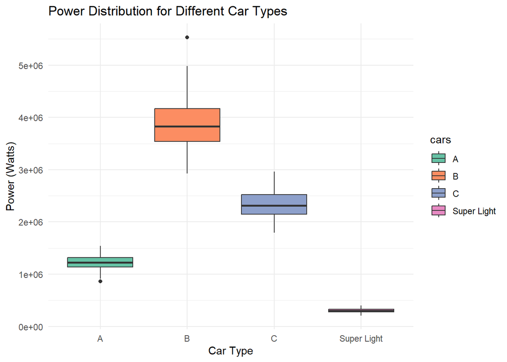

```r
library(ggplot2)

ggplot(powers_pivot, aes(x = cars, y = powers, fill = cars)) +
  geom_boxplot() +
  labs(title = "Power Distribution for Different Car Types",
       x = "Car Type",
       y = "Power (Watts)") +
  theme_minimal() +
  scale_fill_brewer(palette = "Set2") # This line is optional, just to add some color differentiation.
```

## Plot the pmap Data

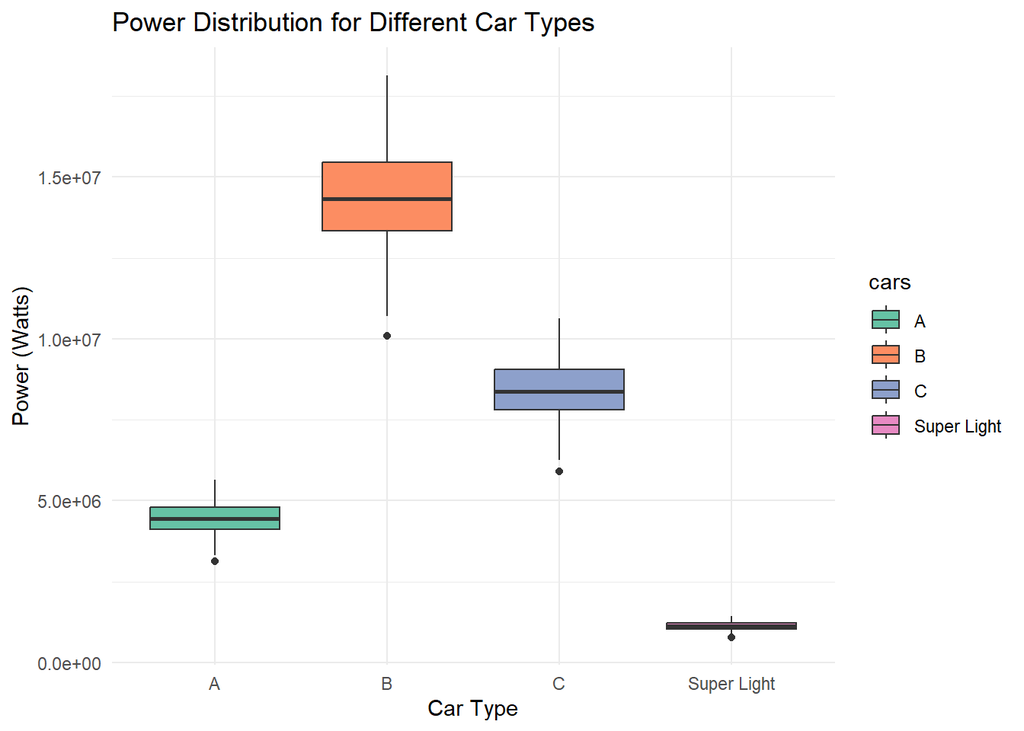

```r
library(ggplot2)

ggplot(powers_pivot_pmap, aes(x = cars, y = powers, fill = cars)) +
  geom_boxplot() +
  labs(title = "Power Distribution for Different Car Types",
       x = "Car Type",
       y = "Power (Watts)") +
  theme_minimal() +
  scale_fill_brewer(palette = "Set2") # This line is optional, just to add some color differentiation.
```